## Project Summary

In this project, I will use R language to analyze the sales data for Big Mart Outlets. The data set has taken from [Big Mart Sales Prediction](https://datahack.analyticsvidhya.com/contest/practice-problem-big-mart-sales-iii/#ProblemStatement). The project goes through 5 phases, Data Exploration, Data Visualization, Data Cleaning, Data manipulation, and Predictive modeling using Machine Learning

### Data Exploration

```r
# Loading Datasets
train <- read.csv("C:\\data\\train_v9rqX0R.csv")
test <- read.csv("C:\\data\\test_AbJTz2l.csv")
```

```r
# Check the sizes
dim(train)
```

```
## [1] 8523   12
```

```r
dim(test)
```

```
## [1] 5681   11
```

```r
# Check the column names and types
str(train)
```

```
## 'data.frame':    8523 obs. of  12 variables:
##  $ Item_Identifier          : chr  "FDA15" "DRC01" "FDN15" "FDX07" ...
##  $ Item_Weight              : num  9.3 5.92 17.5 19.2 8.93 ...
##  $ Item_Fat_Content         : chr  "Low Fat" "Regular" "Low Fat" "Regular" ...
##  $ Item_Visibility          : num  0.016 0.0193 0.0168 0 0 ...
##  $ Item_Type                : chr  "Dairy" "Soft Drinks" "Meat" "Fruits and Vegetables" ...
##  $ Item_MRP                 : num  249.8 48.3 141.6 182.1 53.9 ...
##  $ Outlet_Identifier        : chr  "OUT049" "OUT018" "OUT049" "OUT010" ...
##  $ Outlet_Establishment_Year: int  1999 2009 1999 1998 1987 2009 1987 1985 2002 2007 ...
##  $ Outlet_Size              : chr  "Medium" "Medium" "Medium" "" ...
##  $ Outlet_Location_Type     : chr  "Tier 1" "Tier 3" "Tier 1" "Tier 3" ...
##  $ Outlet_Type              : chr  "Supermarket Type1" "Supermarket Type2" "Supermarket Type1" "Grocery Store" ...
##  $ Item_Outlet_Sales        : num  3735 443 2097 732 995 ...
```

```r
# Convert the categorical columns from character to factor
train$Item_Fat_Content <- as.factor(train$Item_Fat_Content)
train$Outlet_Size <- as.factor(train$Outlet_Size)
train$Outlet_Location_Type <- as.factor(train$Outlet_Location_Type)
train$Outlet_Type <- as.factor(train$Outlet_Type)

levels(train$Item_Fat_Content)
```

```
## [1] "LF"      "low fat" "Low Fat" "reg"     "Regular"
```

```r
levels(train$Outlet_Size)
```

```
## [1] ""       "High"   "Medium" "Small"
```

```r
levels(train$Outlet_Location_Type)
```

```
## [1] "Tier 1" "Tier 2" "Tier 3"
```

```r
levels(train$Outlet_Type)
```

```
## [1] "Grocery Store"     "Supermarket Type1" "Supermarket Type2"
## [4] "Supermarket Type3"
```

```r
# Check for missing values
table(is.na(train))
```

```
##
##  FALSE   TRUE
## 100813   1463
```

```r
# Check the variables which has those missing values
colSums(is.na(train))
```

```
##           Item_Identifier               Item_Weight          Item_Fat_Content
##                         0                      1463                         0
##           Item_Visibility                 Item_Type                  Item_MRP
##                         0                         0                         0
##         Outlet_Identifier Outlet_Establishment_Year               Outlet_Size
##                         0                         0                         0
##      Outlet_Location_Type               Outlet_Type         Item_Outlet_Sales
##                         0                         0                         0
```

```r
summary(train)
```

```
##  Item_Identifier     Item_Weight     Item_Fat_Content Item_Visibility
##  Length:8523        Min.   : 4.555   LF     : 316     Min.   :0.00000
##  Class :character   1st Qu.: 8.774   low fat: 112     1st Qu.:0.02699
##  Mode  :character   Median :12.600   Low Fat:5089     Median :0.05393
##                     Mean   :12.858   reg    : 117     Mean   :0.06613
##                     3rd Qu.:16.850   Regular:2889     3rd Qu.:0.09459
##                     Max.   :21.350                    Max.   :0.32839
##                     NA's   :1463
##   Item_Type            Item_MRP      Outlet_Identifier
##  Length:8523        Min.   : 31.29   Length:8523
##  Class :character   1st Qu.: 93.83   Class :character
##  Mode  :character   Median :143.01   Mode  :character
##                     Mean   :140.99
##                     3rd Qu.:185.64
##                     Max.   :266.89
##
##  Outlet_Establishment_Year Outlet_Size   Outlet_Location_Type
##  Min.   :1985                    :2410   Tier 1:2388
##  1st Qu.:1987              High  : 932   Tier 2:2785
##  Median :1999              Medium:2793   Tier 3:3350
##  Mean   :1998              Small :2388
##  3rd Qu.:2004
##  Max.   :2009
##
##             Outlet_Type   Item_Outlet_Sales
##  Grocery Store    :1083   Min.   :   33.29
##  Supermarket Type1:5577   1st Qu.:  834.25
##  Supermarket Type2: 928   Median : 1794.33
##  Supermarket Type3: 935   Mean   : 2181.29
##                           3rd Qu.: 3101.30
##                           Max.   :13086.97
##
```

Here are some quick inferences drawn from variables in train data set:

1. Item_Fat_Content has mis-matched factor levels.
2. Minimum value of item_visibility is 0. Practically, this is not possible. If an item occupies shelf space in a grocery store, it ought to have some visibility. We’ll treat all 0’s as missing values.
3. Item_Weight has 1463 missing values (already explained above).
4. Outlet_Size has a unmatched factor levels.

### Data Visualization

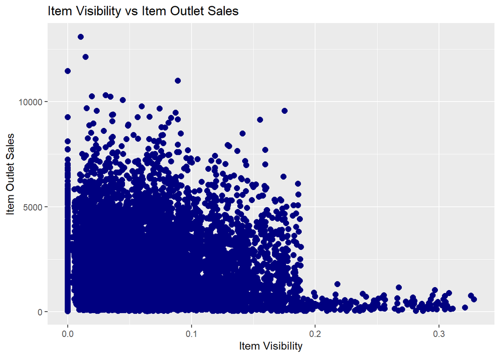

```r
library(ggplot2)
ggplot(train, aes(x= Item_Visibility, y = Item_Outlet_Sales)) + geom_point(size = 2.5, color="navy") + xlab("Item Visibility") + ylab("Item Outlet Sales") + ggtitle("Item Visibility vs Item Outlet Sales")
```

We can see that majority of sales has been obtained from products having visibility less than 0.2. This suggests that item_visibility < 2 must be an important factor in determining sales. Let’s plot few more interesting graphs and explore such hidden stories.

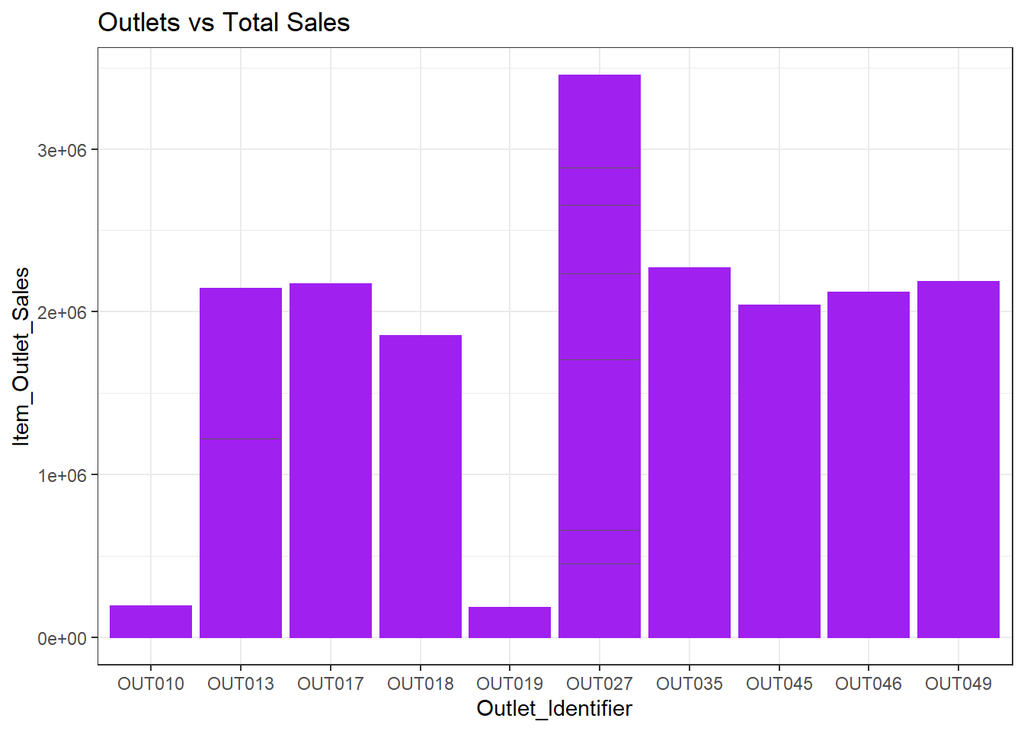

```r
ggplot(train, aes(Outlet_Identifier, Item_Outlet_Sales)) + geom_bar(stat = "identity", color = "purple") +theme(axis.text.x = element_text(angle = 70, vjust = 0.5, color = "black"))  + ggtitle("Outlets vs Total Sales") + theme_bw()
```

Here, we infer that OUT027 has contributed to majority of sales followed by OUT35. OUT10 and OUT19 have probably the least footfall, thereby contributing to the least outlet sales.

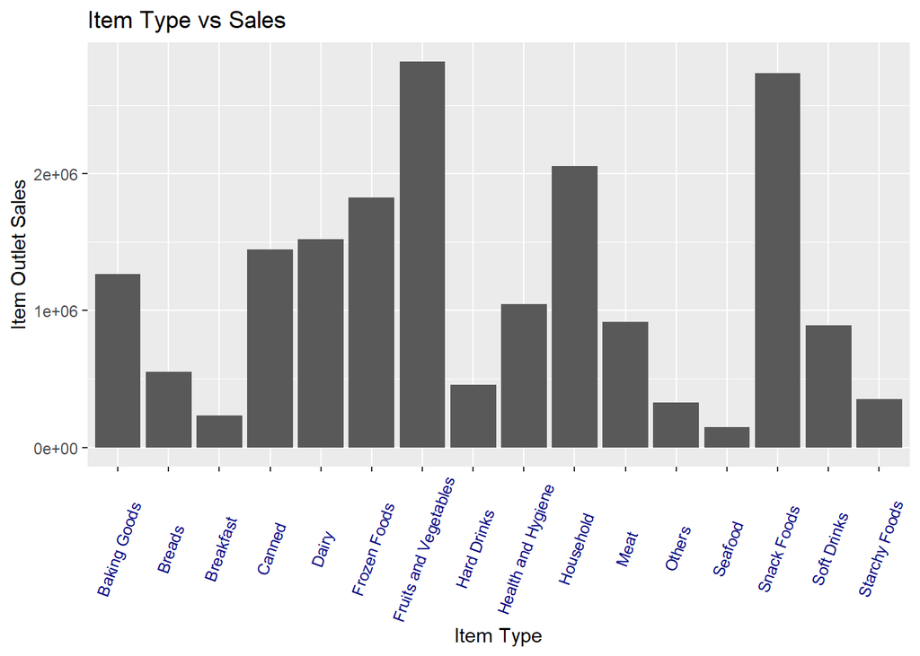

```r
ggplot(train, aes(Item_Type, Item_Outlet_Sales)) + geom_bar( stat = "identity") +theme(axis.text.x = element_text(angle = 70, vjust = 0.5, color = "navy")) + xlab("Item Type") + ylab("Item Outlet Sales")+ggtitle("Item Type vs Sales")
```

From this graph, we can infer that Fruits and Vegetables contribute to the highest amount of outlet sales followed by snack foods and household products.

### Data Cleaning

```r
#Combine the 2 datasets (Train & Test)
dim(train)
```

```
## [1] 8523   12
```

```r
dim(test)
```

```
## [1] 5681   11
```

```r
test$Item_Outlet_Sales <-  1
combi <- rbind(train, test)
```

Impute missing value by median. I’m using median because it is known to be highly robust to outliers. Moreover, for this problem, our evaluation metric is RMSE which is also highly affected by outliers. Hence, median is better in this case.

```r
combi$Item_Weight[is.na(combi$Item_Weight)] <- median(combi$Item_Weight, na.rm = TRUE)
table(is.na(combi$Item_Weight))
```

```
##
## FALSE
## 14204
```

Let’s take up Item_Visibility. In the graph above, we saw item visibility has zero value also, which is practically not feasible. Hence, we’ll consider it as a missing value and once again make the imputation using median

```r
combi$Item_Visibility <- ifelse(combi$Item_Visibility == 0,
                           median(combi$Item_Visibility), combi$Item_Visibility)
```

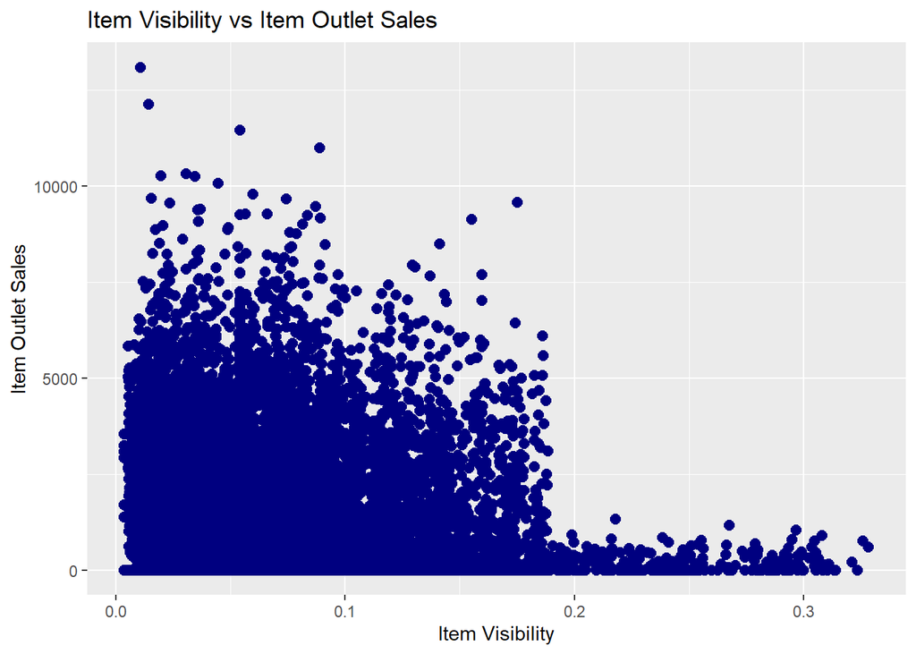

```r
library(ggplot2)
ggplot(combi, aes(x= Item_Visibility, y = Item_Outlet_Sales)) + geom_point(size = 2.5, color="navy") + xlab("Item Visibility") + ylab("Item Outlet Sales") + ggtitle("Item Visibility vs Item Outlet Sales")
```

Handling the mismatched levels in variables

```r
levels(combi$Outlet_Size)[1] <- "Other"
library(plyr)
combi$Item_Fat_Content <- revalue(combi$Item_Fat_Content,
c("LF" = "Low Fat", "reg" = "Regular"))
combi$Item_Fat_Content <- revalue(combi$Item_Fat_Content, c("low fat" = "Low Fat"))
table(combi$Item_Fat_Content)
```

```
##
## Low Fat Regular
##    9185    5019
```

```r
levels(combi$Item_Fat_Content)
```

```
## [1] "Low Fat" "Regular"
```

```r
levels(combi$Outlet_Size)
```

```
## [1] "Other"  "High"   "Medium" "Small"
```

### Data Manipulation

```r
# Count of Outlet Identifiers
library(dplyr)
a <- combi%>%
            group_by(Outlet_Identifier)%>%
            tally()
head(a)
```

```
## # A tibble: 6 x 2
##   Outlet_Identifier     n
##   <chr>             <int>
## 1 OUT010              925
## 2 OUT013             1553
## 3 OUT017             1543
## 4 OUT018             1546
## 5 OUT019              880
## 6 OUT027             1559
```

```r
names(a)[2] <- "Outlet_Count"
combi <- full_join(a, combi, by = "Outlet_Identifier")
```

```r
head(combi)
```

```
## # A tibble: 6 x 13
##   Outlet_Identifi~ Outlet_Count Item_Identifier Item_Weight Item_Fat_Content
##   <chr>                   <int> <chr>                 <dbl> <fct>
## 1 OUT010                    925 FDX07                 19.2  Regular
## 2 OUT010                    925 FDE51                  5.92 Regular
## 3 OUT010                    925 FDV38                 19.2  Low Fat
## 4 OUT010                    925 FDM39                  6.42 Low Fat
## 5 OUT010                    925 FDC46                 17.7  Low Fat
## 6 OUT010                    925 FDW20                 20.8  Low Fat
## # ... with 8 more variables: Item_Visibility <dbl>, Item_Type <chr>,
## #   Item_MRP <dbl>, Outlet_Establishment_Year <int>, Outlet_Size <fct>,
## #   Outlet_Location_Type <fct>, Outlet_Type <fct>, Item_Outlet_Sales <dbl>
```

```r
# Count of Item Identifiers
b <- combi%>%
          group_by(Item_Identifier)%>%
          tally()

names(b)[2] <- "Item_Count"
```

```r
head(b)
```

```
## # A tibble: 6 x 2
##   Item_Identifier Item_Count
##   <chr>                <int>
## 1 DRA12                    9
## 2 DRA24                   10
## 3 DRA59                   10
## 4 DRB01                    8
## 5 DRB13                    9
## 6 DRB24                    8
```

```r
combi <- merge(b, combi, by = "Item_Identifier")
head(combi)
```

```
##   Item_Identifier Item_Count Outlet_Identifier Outlet_Count Item_Weight
## 1           DRA12          9            OUT049         1550        11.6
## 2           DRA12          9            OUT010          925        11.6
## 3           DRA12          9            OUT017         1543        11.6
## 4           DRA12          9            OUT027         1559        12.6
## 5           DRA12          9            OUT035         1550        11.6
## 6           DRA12          9            OUT046         1550        11.6
##   Item_Fat_Content Item_Visibility   Item_Type Item_MRP
## 1          Low Fat      0.04100956 Soft Drinks 141.0154
## 2          Low Fat      0.06853504 Soft Drinks 143.0154
## 3          Low Fat      0.04117751 Soft Drinks 140.3154
## 4          Low Fat      0.04074762 Soft Drinks 140.0154
## 5          Low Fat      0.05402054 Soft Drinks 141.9154
## 6          Low Fat      0.04094590 Soft Drinks 142.9154
##   Outlet_Establishment_Year Outlet_Size Outlet_Location_Type       Outlet_Type
## 1                      1999      Medium               Tier 1 Supermarket Type1
## 2                      1998       Other               Tier 3     Grocery Store
## 3                      2007       Other               Tier 2 Supermarket Type1
## 4                      1985      Medium               Tier 3 Supermarket Type3
## 5                      2004       Small               Tier 2 Supermarket Type1
## 6                      1997       Small               Tier 1 Supermarket Type1
##   Item_Outlet_Sales
## 1            1.0000
## 2          283.6308
## 3         2552.6772
## 4            1.0000
## 5          992.7078
## 6            1.0000
```

```r
c <- combi%>%
           select(Outlet_Establishment_Year)%>%
           mutate(Outlet_Year = 2013 - combi$Outlet_Establishment_Year)

c = c %>% distinct(Outlet_Establishment_Year,Outlet_Year)
head(c)
```

```
##   Outlet_Establishment_Year Outlet_Year
## 1                      1999          14
## 2                      1998          15
## 3                      2007           6
## 4                      1985          28
## 5                      2004           9
## 6                      1997          16
```

```r
combi <- merge(c, combi, by = "Outlet_Establishment_Year")
head(combi)
```

```
##   Outlet_Establishment_Year Outlet_Year Item_Identifier Item_Count
## 1                      1985          28           FDW37          8
## 2                      1985          28           FDA55          9
## 3                      1985          28           FDR33         10
## 4                      1985          28           FDM12         10
## 5                      1985          28           DRF48          9
## 6                      1985          28           DRD12          8
##   Outlet_Identifier Outlet_Count Item_Weight Item_Fat_Content Item_Visibility
## 1            OUT027         1559        12.6          Low Fat      0.12344967
## 2            OUT027         1559        12.6          Regular      0.05671306
## 3            OUT019          880        12.6          Low Fat      0.04690397
## 4            OUT027         1559        12.6          Regular      0.06957842
## 5            OUT027         1559        12.6          Low Fat      0.05155062
## 6            OUT027         1559        12.6          Low Fat      0.05402054
##               Item_Type Item_MRP Outlet_Size Outlet_Location_Type
## 1                Canned  89.7488      Medium               Tier 3
## 2 Fruits and Vegetables 223.8088      Medium               Tier 3
## 3           Snack Foods 110.6570       Small               Tier 1
## 4          Baking Goods 190.2214      Medium               Tier 3
## 5           Soft Drinks 186.3898      Medium               Tier 3
## 6           Soft Drinks  89.4146      Medium               Tier 3
##         Outlet_Type Item_Outlet_Sales
## 1 Supermarket Type3          1901.525
## 2 Supermarket Type3          5592.720
## 3     Grocery Store           659.142
## 4 Supermarket Type3             1.000
## 5 Supermarket Type3             1.000
## 6 Supermarket Type3          2645.223
```

```r
q <- substr(combi$Item_Identifier,1,2)
q <- gsub("FD","Food",q)
q <- gsub("DR","Drinks",q)
q <- gsub("NC","Non-Consumable",q)
table(q)
```

```
## q
##         Drinks           Food Non-Consumable
##           1317          10201           2686
```

```r
combi$Item_Type_New <- q
```

```r
# Label Encoding
combi$Item_Fat_Content <- ifelse(combi$Item_Fat_Content == "Regular",1,0)
```

```r
# Convert the type of the new variable to factor
combi$Item_Type_New <- as.factor(combi$Item_Type_New)
str(combi)
```

```
## 'data.frame':    14204 obs. of  16 variables:
##  $ Outlet_Establishment_Year: int  1985 1985 1985 1985 1985 1985 1985 1985 1985 1985 ...
##  $ Outlet_Year              : num  28 28 28 28 28 28 28 28 28 28 ...
##  $ Item_Identifier          : chr  "FDW37" "FDA55" "FDR33" "FDM12" ...
##  $ Item_Count               : int  8 9 10 10 9 8 8 10 9 9 ...
##  $ Outlet_Identifier        : chr  "OUT027" "OUT027" "OUT019" "OUT027" ...
##  $ Outlet_Count             : int  1559 1559 880 1559 1559 1559 1559 1559 1559 1559 ...
##  $ Item_Weight              : num  12.6 12.6 12.6 12.6 12.6 12.6 12.6 12.6 12.6 12.6 ...
##  $ Item_Fat_Content         : num  0 1 0 1 0 0 0 0 0 1 ...
##  $ Item_Visibility          : num  0.1234 0.0567 0.0469 0.0696 0.0516 ...
##  $ Item_Type                : chr  "Canned" "Fruits and Vegetables" "Snack Foods" "Baking Goods" ...
##  $ Item_MRP                 : num  89.7 223.8 110.7 190.2 186.4 ...
##  $ Outlet_Size              : Factor w/ 4 levels "Other","High",..: 3 3 4 3 3 3 3 3 3 3 ...
##  $ Outlet_Location_Type     : Factor w/ 3 levels "Tier 1","Tier 2",..: 3 3 1 3 3 3 3 3 3 3 ...
##  $ Outlet_Type              : Factor w/ 4 levels "Grocery Store",..: 4 4 1 4 4 4 4 4 4 4 ...
##  $ Item_Outlet_Sales        : num  1902 5593 659 1 1 ...
##  $ Item_Type_New            : Factor w/ 3 levels "Drinks","Food",..: 2 2 2 2 1 1 2 2 2 2 ...
```

```r
# One Hot Encoding
library(dummies)
combi <- dummy.data.frame(combi, names = c('Outlet_Size','Outlet_Location_Type','Outlet_Type', 'Item_Type_New'),  sep='_')
str(combi)
```

```
## 'data.frame':    14204 obs. of  26 variables:
##  $ Outlet_Establishment_Year    : int  1985 1985 1985 1985 1985 1985 1985 1985 1985 1985 ...
##  $ Outlet_Year                  : num  28 28 28 28 28 28 28 28 28 28 ...
##  $ Item_Identifier              : chr  "FDW37" "FDA55" "FDR33" "FDM12" ...
##  $ Item_Count                   : int  8 9 10 10 9 8 8 10 9 9 ...
##  $ Outlet_Identifier            : chr  "OUT027" "OUT027" "OUT019" "OUT027" ...
##  $ Outlet_Count                 : int  1559 1559 880 1559 1559 1559 1559 1559 1559 1559 ...
##  $ Item_Weight                  : num  12.6 12.6 12.6 12.6 12.6 12.6 12.6 12.6 12.6 12.6 ...
##  $ Item_Fat_Content             : num  0 1 0 1 0 0 0 0 0 1 ...
##  $ Item_Visibility              : num  0.1234 0.0567 0.0469 0.0696 0.0516 ...
##  $ Item_Type                    : chr  "Canned" "Fruits and Vegetables" "Snack Foods" "Baking Goods" ...
##  $ Item_MRP                     : num  89.7 223.8 110.7 190.2 186.4 ...
##  $ Outlet_Size_Other            : int  0 0 0 0 0 0 0 0 0 0 ...
##  $ Outlet_Size_High             : int  0 0 0 0 0 0 0 0 0 0 ...
##  $ Outlet_Size_Medium           : int  1 1 0 1 1 1 1 1 1 1 ...
```

[output cut: 17 more lines]

### Predictive Modeling using Machine Learning

```r
# drop the columns which have either been converted using other variables or are identifier variables
combi <- select(combi, -c(Item_Identifier, Outlet_Identifier, Item_Fat_Content,                                Outlet_Establishment_Year,Item_Type))
str(combi)
```

```
## 'data.frame':    14204 obs. of  21 variables:
##  $ Outlet_Year                  : num  28 28 28 28 28 28 28 28 28 28 ...
##  $ Item_Count                   : int  8 9 10 10 9 8 8 10 9 9 ...
##  $ Outlet_Count                 : int  1559 1559 880 1559 1559 1559 1559 1559 1559 1559 ...
##  $ Item_Weight                  : num  12.6 12.6 12.6 12.6 12.6 12.6 12.6 12.6 12.6 12.6 ...
##  $ Item_Visibility              : num  0.1234 0.0567 0.0469 0.0696 0.0516 ...
##  $ Item_MRP                     : num  89.7 223.8 110.7 190.2 186.4 ...
##  $ Outlet_Size_Other            : int  0 0 0 0 0 0 0 0 0 0 ...
##  $ Outlet_Size_High             : int  0 0 0 0 0 0 0 0 0 0 ...
##  $ Outlet_Size_Medium           : int  1 1 0 1 1 1 1 1 1 1 ...
##  $ Outlet_Size_Small            : int  0 0 1 0 0 0 0 0 0 0 ...
##  $ Outlet_Location_Type_Tier 1  : int  0 0 1 0 0 0 0 0 0 0 ...
##  $ Outlet_Location_Type_Tier 2  : int  0 0 0 0 0 0 0 0 0 0 ...
##  $ Outlet_Location_Type_Tier 3  : int  1 1 0 1 1 1 1 1 1 1 ...
##  $ Outlet_Type_Grocery Store    : int  0 0 1 0 0 0 0 0 0 0 ...
##  $ Outlet_Type_Supermarket Type1: int  0 0 0 0 0 0 0 0 0 0 ...
##  $ Outlet_Type_Supermarket Type2: int  0 0 0 0 0 0 0 0 0 0 ...
##  $ Outlet_Type_Supermarket Type3: int  1 1 0 1 1 1 1 1 1 1 ...
##  $ Item_Outlet_Sales            : num  1902 5593 659 1 1 ...
##  $ Item_Type_New_Drinks         : int  0 0 0 0 1 1 0 0 0 0 ...
##  $ Item_Type_New_Food           : int  1 1 1 1 0 0 1 1 1 1 ...
##  $ Item_Type_New_Non-Consumable : int  0 0 0 0 0 0 0 0 0 0 ...
```

```r
# devide the dataset into train and test
new_train <- combi[1:nrow(train),]
new_test <- combi[-(1:nrow(train)),]
```

```r
# Build our Linear Regression model
linear_model <- lm(Item_Outlet_Sales ~ ., data = new_train)
summary(linear_model)
```

```
##
## Call:
## lm(formula = Item_Outlet_Sales ~ ., data = new_train)
##
## Residuals:
##     Min      1Q  Median      3Q     Max
## -3378.2 -1082.9   -37.3   742.2 10050.3
##
## Coefficients: (8 not defined because of singularities)
##                                   Estimate Std. Error t value Pr(>|t|)
## (Intercept)                     -2145.9881   827.4669  -2.593 0.009518 **
## Outlet_Year                         0.4943    14.6869   0.034 0.973151
## Item_Count                         28.3996    24.1163   1.178 0.238986
## Outlet_Count                        1.7458     0.2229   7.831 5.41e-15 ***
## Item_Weight                         2.2582     4.2823   0.527 0.597971
## Item_Visibility                  -227.4356   340.4925  -0.668 0.504177
## Item_MRP                            9.0449     0.2711  33.359  < 2e-16 ***
## Outlet_Size_Other                -862.1740   348.8665  -2.471 0.013480 *
## Outlet_Size_High                 -785.9564   106.8290  -7.357 2.05e-13 ***
## Outlet_Size_Medium                 39.9653    69.0525   0.579 0.562762
## Outlet_Size_Small                       NA         NA      NA       NA
## `Outlet_Location_Type_Tier 1`    -786.0833   214.7842  -3.660 0.000254 ***
## `Outlet_Location_Type_Tier 2`           NA         NA      NA       NA
## `Outlet_Location_Type_Tier 3`           NA         NA      NA       NA
## `Outlet_Type_Grocery Store`             NA         NA      NA       NA
## `Outlet_Type_Supermarket Type1`         NA         NA      NA       NA
## `Outlet_Type_Supermarket Type2`         NA         NA      NA       NA
## `Outlet_Type_Supermarket Type3`         NA         NA      NA       NA
## Item_Type_New_Drinks              -26.2149    67.2210  -0.390 0.696560
## Item_Type_New_Food                 56.5611    43.7396   1.293 0.196000
## `Item_Type_New_Non-Consumable`          NA         NA      NA       NA
## ---
## Signif. codes:  0 '***' 0.001 '**' 0.01 '*' 0.05 '.' 0.1 ' ' 1
##
## Residual standard error: 1550 on 8510 degrees of freedom
## Multiple R-squared:  0.233,  Adjusted R-squared:  0.2319
## F-statistic: 215.5 on 12 and 8510 DF,  p-value: < 2.2e-16
```

Adjusted R² measures the goodness of fit of a regression model. Higher the R², better is the model. Our R² = 0.2319. It means we really did something drastically wrong.

As we know, correlated predictor variables brings down the model accuracy. Let’s find out the amount of correlation present in our predictor variables. This can be simply calculated using:

```r
cor(new_train)
```

```
##                                 Outlet_Year   Item_Count  Outlet_Count
## Outlet_Year                    1.000000e+00  0.018579412 -0.0764674894
## Item_Count                     1.857941e-02  1.000000000 -0.2409393610
## Outlet_Count                  -7.646749e-02 -0.240939361  1.0000000000
## Item_Weight                   -1.142695e-02 -0.014645842  0.0079478331
## Item_Visibility                3.633614e-02  0.099253984 -0.3431642520
## Item_MRP                       7.871695e-05  0.002860730  0.0003212289
## Outlet_Size_Other             -4.805563e-01  0.109355994 -0.4562232941
## Outlet_Size_High               4.033892e-01 -0.059700160  0.2451236809
## Outlet_Size_Medium             6.263751e-02 -0.095618832  0.3978369126
## Outlet_Size_Small             -1.383795e-02  0.062459897 -0.2560607514
## Outlet_Location_Type_Tier 1   -3.790734e-01  0.012168590 -0.0465361119
## Outlet_Location_Type_Tier 2   -3.694618e-01 -0.029470703  0.1257332242
## Outlet_Location_Type_Tier 3    5.536320e-01  0.001789128 -0.0130085334
## Outlet_Type_Grocery Store      6.837141e-02  0.240665631 -0.9991606831
## Outlet_Type_Supermarket Type1 -4.929801e-01 -0.152272216  0.6323974722
## Outlet_Type_Supermarket Type2            NA           NA            NA
## Outlet_Type_Supermarket Type3  5.510294e-01 -0.061821874  0.2563903066
## Item_Outlet_Sales              8.489250e-02 -0.064512029  0.3174451568
## Item_Type_New_Drinks          -1.374789e-02 -0.018903693  0.0075252718
## Item_Type_New_Food             2.581601e-03  0.019908905 -0.0006507127
## Item_Type_New_Non-Consumable   7.327272e-03 -0.008785802 -0.0048897683
##                                Item_Weight Item_Visibility      Item_MRP
## Outlet_Year                   -0.011426953     0.036336140  7.871695e-05
## Item_Count                    -0.014645842     0.099253984  2.860730e-03
## Outlet_Count                   0.007947833    -0.343164252  3.212289e-04
## Item_Weight                    1.000000000    -0.015188496  3.158494e-02
## Item_Visibility               -0.015188496     1.000000000 -4.023071e-03
## Item_MRP                       0.031584938    -0.004023071  1.000000e+00
## Outlet_Size_Other             -0.005495133     0.150960369 -1.912157e-04
## Outlet_Size_High               0.007884721    -0.082522485  1.042092e-03
## Outlet_Size_Medium            -0.004102252    -0.137696357  1.173405e-03
## Outlet_Size_Small              0.002181739     0.092393204 -1.983833e-03
## Outlet_Location_Type_Tier 1    0.009441659     0.014712664 -7.860293e-04
## Outlet_Location_Type_Tier 2   -0.008736642    -0.041676402 -1.548301e-03
## Outlet_Location_Type_Tier 3   -0.005299221     0.005023847  1.518190e-03
## Outlet_Type_Grocery Store     -0.007849184     0.342548444 -2.541984e-04
## Outlet_Type_Supermarket Type1  0.018223058    -0.221046994  8.694544e-05
## Outlet_Type_Supermarket Type2           NA              NA            NA
## Outlet_Type_Supermarket Type3 -0.014744574    -0.082541353  1.587179e-04
```

[output cut: 231 more lines]

```
## Outlet_Size_Other                            -0.0105656247
## Outlet_Size_High                              0.0007836792
## Outlet_Size_Medium                            0.0034043318
## Outlet_Size_Small                             0.0044475613
## Outlet_Location_Type_Tier 1                   0.0055724627
## Outlet_Location_Type_Tier 2                  -0.0213911887
## Outlet_Location_Type_Tier 3                   0.0045560924
## Outlet_Type_Grocery Store                     0.0049951790
## Outlet_Type_Supermarket Type1                -0.0059482059
## Outlet_Type_Supermarket Type2                           NA
## Outlet_Type_Supermarket Type3                 0.0022413908
## Item_Outlet_Sales                            -0.0084152744
## Item_Type_New_Drinks                         -0.1550803482
## Item_Type_New_Food                           -0.7665419068
## Item_Type_New_Non-Consumable                  1.0000000000
```

```r
cor(new_train$Outlet_Count, new_train$`Outlet_Type_Grocery Store`)
```

```
## [1] -0.9991607
```

Let’s try to create a more robust regression mode

```r
#load data
train <- read.csv("C:\\data\\train_v9rqX0R.csv")
test <- read.csv("C:\\data\\test_AbJTz2l.csv")
```

```r
#create a new variable in test file
test$Item_Outlet_Sales <- 1

#combine train and test data
combi <- rbind(train, test)
```

```r
#impute missing value in Item_Weight
combi$Item_Weight[is.na(combi$Item_Weight)] <- median(combi$Item_Weight, na.rm = TRUE)
```

```r
#impute 0 in item_visibility
combi$Item_Visibility <- ifelse(combi$Item_Visibility == 0, median(combi$Item_Visibility), combi$Item_Visibility)
```

```r
combi$Item_Fat_Content <- as.factor(combi$Item_Fat_Content)
combi$Outlet_Size <- as.factor(combi$Outlet_Size)
combi$Outlet_Location_Type <- as.factor(combi$Outlet_Location_Type)
combi$Outlet_Type <- as.factor(combi$Outlet_Type)

#rename level in Outlet_Size
levels(combi$Outlet_Size)[1] <- "Other"

#rename levels of Item_Fat_Content
library(plyr)
combi$Item_Fat_Content <- revalue(combi$Item_Fat_Content,c("LF" = "Low Fat", "reg" =                                   "Regular"))
combi$Item_Fat_Content <- revalue(combi$Item_Fat_Content, c("low fat" = "Low Fat"))
```

```r
levels(combi$Item_Fat_Content)
```

```
## [1] "Low Fat" "Regular"
```

```r
levels(combi$Outlet_Size)
```

```
## [1] "Other"  "High"   "Medium" "Small"
```

```r
#create a new column 2013 - Year
combi$Year <- 2013 - combi$Outlet_Establishment_Year
```

```r
#drop variables not required in modeling
library(dplyr)
combi <- select(combi, -c(Item_Identifier, Outlet_Identifier, Outlet_Establishment_Year))
```

```r
#divide data set
new_train <- combi[1:nrow(train),]
new_test <- combi[-(1:nrow(train)),]
```

```r
#linear regression
linear_model <- lm(Item_Outlet_Sales ~ ., data = new_train)
summary(linear_model)
```

```
##
## Call:
## lm(formula = Item_Outlet_Sales ~ ., data = new_train)
##
## Residuals:
##     Min      1Q  Median      3Q     Max
## -4336.2  -680.8   -89.8   568.3  7946.1
##
## Coefficients:
##                                  Estimate Std. Error t value Pr(>|t|)
## (Intercept)                    -977.43100  304.34139  -3.212 0.001325 **
## Item_Weight                      -0.51139    2.91490  -0.175 0.860738
## Item_Fat_ContentRegular          40.50509   28.23186   1.435 0.151401
## Item_Visibility                -255.77401  263.78199  -0.970 0.332253
## Item_TypeBreads                   5.25222   84.04714   0.062 0.950173
## Item_TypeBreakfast                6.26997  116.59546   0.054 0.957115
## Item_TypeCanned                  25.28447   62.76864   0.403 0.687091
## Item_TypeDairy                  -41.05177   62.22667  -0.660 0.509456
## Item_TypeFrozen Foods           -28.00838   58.86986  -0.476 0.634252
## Item_TypeFruits and Vegetables   29.84893   54.95872   0.543 0.587065
## Item_TypeHard Drinks             -0.07955   90.18745  -0.001 0.999296
## Item_TypeHealth and Hygiene     -10.09434   68.02370  -0.148 0.882035
## Item_TypeHousehold              -39.12266   59.92886  -0.653 0.513891
## Item_TypeMeat                    -0.35463   70.66270  -0.005 0.995996
## Item_TypeOthers                 -21.27266   98.62482  -0.216 0.829232
## Item_TypeSeafood                184.55373  148.00848   1.247 0.212464
## Item_TypeSnack Foods            -11.48660   55.25066  -0.208 0.835312
## Item_TypeSoft Drinks            -27.46544   70.16973  -0.391 0.695501
## Item_TypeStarchy Foods           21.86315  103.04028   0.212 0.831971
## Item_MRP                         15.56477    0.19769  78.733  < 2e-16 ***
## Outlet_SizeHigh                 849.13529  256.29910   3.313 0.000927 ***
## Outlet_SizeMedium               170.93952   71.08120   2.405 0.016200 *
## Outlet_SizeSmall                144.05363   45.67140   3.154 0.001615 **
## Outlet_Location_TypeTier 2     -100.36636   90.23496  -1.112 0.266050
## Outlet_Location_TypeTier 3     -326.31974  154.89294  -2.107 0.035169 *
## Outlet_TypeSupermarket Type1   1473.06659  140.73922  10.467  < 2e-16 ***
## Outlet_TypeSupermarket Type2   1076.77568  136.08116   7.913 2.83e-15 ***
## Outlet_TypeSupermarket Type3   3639.29114  178.13923  20.429  < 2e-16 ***
## Year                            -34.82155   10.49271  -3.319 0.000908 ***
## ---
## Signif. codes:  0 '***' 0.001 '**' 0.01 '*' 0.05 '.' 0.1 ' ' 1
##
## Residual standard error: 1129 on 8494 degrees of freedom
## Multiple R-squared:  0.5637, Adjusted R-squared:  0.5623
## F-statistic:   392 on 28 and 8494 DF,  p-value: < 2.2e-16
```

Now we have got R² = 0.5623 which means it improved than before.

Let’s check out regression plot to find out more ways to improve this model.

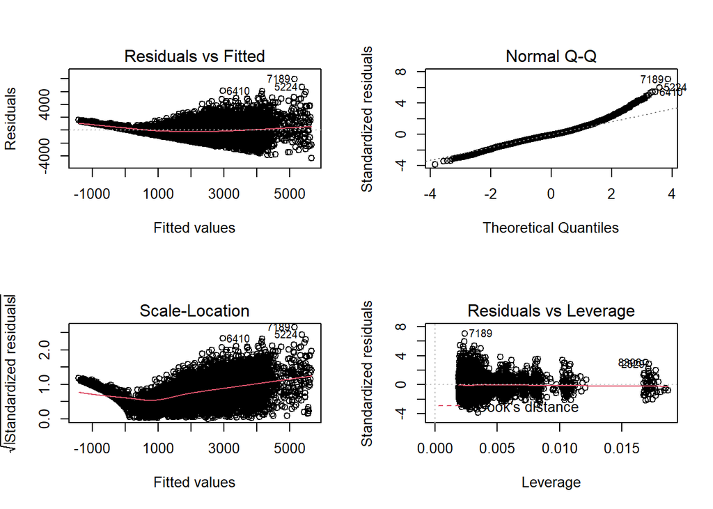

```r
par(mfrow=c(2,2))
plot(linear_model)
```

The shape of the Residuals graph shows that the model is suffering from heteroskedasticity (unequal variance in error terms), which can be solved by taking the log of response variable:

```r
linear_model <- lm(log(Item_Outlet_Sales) ~ ., data = new_train)
summary(linear_model)
```

```
##
## Call:
## lm(formula = log(Item_Outlet_Sales) ~ ., data = new_train)
##
## Residuals:
##      Min       1Q   Median       3Q      Max
## -2.30630 -0.29386  0.06823  0.37926  1.35991
##
## Coefficients:
##                                  Estimate Std. Error t value Pr(>|t|)
## (Intercept)                     4.763e+00  1.450e-01  32.857  < 2e-16 ***
## Item_Weight                    -4.195e-04  1.388e-03  -0.302  0.76254
## Item_Fat_ContentRegular         1.359e-02  1.345e-02   1.011  0.31208
## Item_Visibility                -3.162e-02  1.256e-01  -0.252  0.80129
## Item_TypeBreads                 2.819e-02  4.003e-02   0.704  0.48137
## Item_TypeBreakfast             -6.944e-02  5.554e-02  -1.250  0.21120
## Item_TypeCanned                 2.532e-02  2.990e-02   0.847  0.39712
## Item_TypeDairy                 -6.904e-02  2.964e-02  -2.329  0.01987 *
## Item_TypeFrozen Foods          -5.422e-02  2.804e-02  -1.934  0.05318 .
## Item_TypeFruits and Vegetables -4.600e-03  2.618e-02  -0.176  0.86051
## Item_TypeHard Drinks           -2.201e-02  4.296e-02  -0.512  0.60849
## Item_TypeHealth and Hygiene     1.126e-02  3.240e-02   0.347  0.72826
## Item_TypeHousehold             -2.632e-02  2.855e-02  -0.922  0.35654
## Item_TypeMeat                   2.239e-02  3.366e-02   0.665  0.50586
## Item_TypeOthers                 2.354e-03  4.698e-02   0.050  0.96004
## Item_TypeSeafood                5.572e-03  7.050e-02   0.079  0.93700
## Item_TypeSnack Foods           -1.425e-03  2.632e-02  -0.054  0.95683
## Item_TypeSoft Drinks           -2.241e-02  3.342e-02  -0.671  0.50247
## Item_TypeStarchy Foods         -4.744e-02  4.908e-02  -0.967  0.33376
## Item_MRP                        8.316e-03  9.416e-05  88.313  < 2e-16 ***
## Outlet_SizeHigh                 3.547e-01  1.221e-01   2.905  0.00368 **
## Outlet_SizeMedium               8.223e-02  3.386e-02   2.429  0.01517 *
## Outlet_SizeSmall                6.748e-02  2.175e-02   3.102  0.00193 **
## Outlet_Location_TypeTier 2     -4.215e-02  4.298e-02  -0.981  0.32673
## Outlet_Location_TypeTier 3     -1.566e-01  7.378e-02  -2.122  0.03387 *
## Outlet_TypeSupermarket Type1    1.744e+00  6.704e-02  26.013  < 2e-16 ***
## Outlet_TypeSupermarket Type2    1.540e+00  6.482e-02  23.753  < 2e-16 ***
## Outlet_TypeSupermarket Type3    2.607e+00  8.485e-02  30.728  < 2e-16 ***
## Year                           -1.495e-02  4.998e-03  -2.992  0.00278 **
## ---
## Signif. codes:  0 '***' 0.001 '**' 0.01 '*' 0.05 '.' 0.1 ' ' 1
##
## Residual standard error: 0.5378 on 8494 degrees of freedom
## Multiple R-squared:  0.7214, Adjusted R-squared:  0.7205
## F-statistic: 785.4 on 28 and 8494 DF,  p-value: < 2.2e-16
```

We have got an improved model with R² = 0.72

```r
# Check our RMSE
library(Metrics)
rmse(new_train$Item_Outlet_Sales, exp(linear_model$fitted.values))
```

```
## [1] 1140.004
```

```r
# Building a decision tree

# Loading required libraries
library(rpart)
library(e1071)
library(rpart.plot)
library(caret)
# Setting the tree control parameters
fitControl <- trainControl(method = "cv", number = 5)
cartGrid <- expand.grid(.cp=(1:50)*0.01)

tree_model <- train(Item_Outlet_Sales ~ ., data = new_train, method = "rpart", trControl = fitControl, tuneGrid = cartGrid)
print(tree_model)
```

```
## CART
##
## 8523 samples
##    9 predictor
##
## No pre-processing
## Resampling: Cross-Validated (5 fold)
## Summary of sample sizes: 6817, 6819, 6818, 6819, 6819
## Resampling results across tuning parameters:
##
##   cp    RMSE      Rsquared   MAE
##   0.01  1115.252  0.5729389   799.5459
##   0.02  1176.667  0.5246647   863.2441
##   0.03  1197.340  0.5078670   879.2130
##   0.04  1254.105  0.4602709   948.1774
##   0.05  1254.105  0.4602709   948.1774
##   0.06  1316.202  0.4056198  1019.2008
##   0.07  1316.202  0.4056198  1019.2008
##   0.08  1316.202  0.4056198  1019.2008
##   0.09  1491.760  0.2359412  1131.4605
##   0.10  1491.760  0.2359412  1131.4605
##   0.11  1491.760  0.2359412  1131.4605
##   0.12  1491.760  0.2359412  1131.4605
##   0.13  1491.760  0.2359412  1131.4605
##   0.14  1491.760  0.2359412  1131.4605
##   0.15  1491.760  0.2359412  1131.4605
##   0.16  1491.760  0.2359412  1131.4605
##   0.17  1491.760  0.2359412  1131.4605
##   0.18  1491.760  0.2359412  1131.4605
##   0.19  1491.760  0.2359412  1131.4605
##   0.20  1491.760  0.2359412  1131.4605
##   0.21  1491.760  0.2359412  1131.4605
##   0.22  1491.760  0.2359412  1131.4605
##   0.23  1491.760  0.2359412  1131.4605
##   0.24  1666.413  0.2190887  1309.3863
##   0.25  1706.342        NaN  1346.6160
##   0.26  1706.342        NaN  1346.6160
##   0.27  1706.342        NaN  1346.6160
##   0.28  1706.342        NaN  1346.6160
##   0.29  1706.342        NaN  1346.6160
```

[output cut: 9 more lines]

```
##   0.39  1706.342        NaN  1346.6160
##   0.40  1706.342        NaN  1346.6160
##   0.41  1706.342        NaN  1346.6160
##   0.42  1706.342        NaN  1346.6160
##   0.43  1706.342        NaN  1346.6160
##   0.44  1706.342        NaN  1346.6160
##   0.45  1706.342        NaN  1346.6160
##   0.46  1706.342        NaN  1346.6160
##   0.47  1706.342        NaN  1346.6160
##   0.48  1706.342        NaN  1346.6160
##   0.49  1706.342        NaN  1346.6160
##   0.50  1706.342        NaN  1346.6160
##
## RMSE was used to select the optimal model using the smallest value.
## The final value used for the model was cp = 0.01.
```

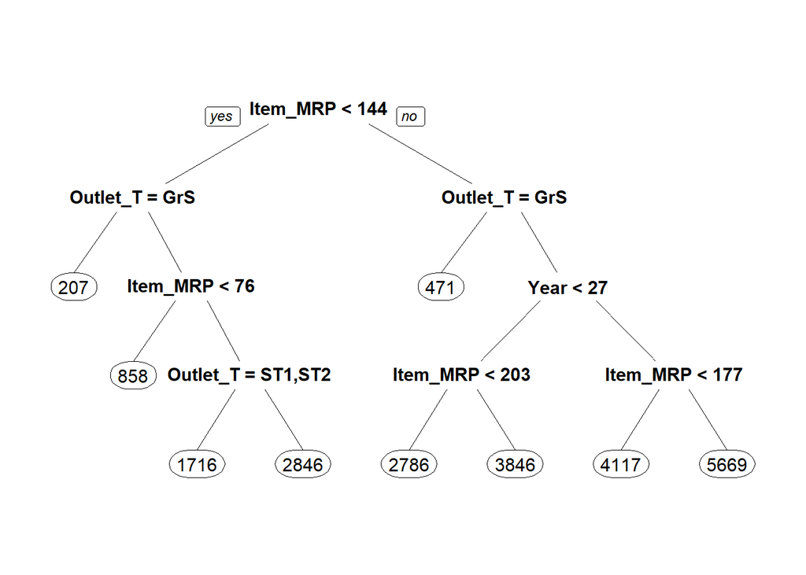

```r
main_tree <- rpart(Item_Outlet_Sales ~ ., data = new_train, control = rpart.control(cp=0.01))
prp(main_tree)
```

```r
pre_score <- predict(main_tree, type = "vector")
rmse(new_train$Item_Outlet_Sales, pre_score)
```

```
## [1] 1102.774
```

```r
# Predict the test data using the decision tree
main_predict <- predict(main_tree, newdata = new_test, type = "vector")
sub_file <- data.frame(Item_Identifier = test$Item_Identifier, Outlet_Identifier = test$Outlet_Identifier, Item_Outlet_Sales = main_predict)
write.csv(sub_file, 'Decision_tree_sales.csv')
```